# Question

Quadratic polynomial $p$ is defined below in standard form.
$$p(x)~=~{4}x^{2}+{24}x+{34}$$

By [completing the square](https://en.wikipedia.org/wiki/Completing_the_square), you can rewrite the quadratic polynomial in vertex form:

$$p(x) = a(x-h)^2+k$$

where $(h,k)$ is the vertex of the parabola. Determine the coordinates of the vertex of quadratic polynomial $p$.

- $h=$ ##ANSWER1##
- $k=$ ##ANSWER2##

## Answerlist

- -10
- -9
- -8
- -7
- -6
- -5
- -4
- -3
- -2
- -1
- 0
- 1
- 2
- 3
- 4
- 5
- 6
- 7
- 8
- 9
- 10
- -10
- -9
- -8
- -7
- -6
- -5
- -4
- -3
- -2
- -1
- 0
- 1
- 2
- 3
- 4
- 5
- 6
- 7
- 8
- 9
- 10

# Solution

We are given $p(x)~=~{4}x^{2}+{24}x+{34}$. From the first two terms, factor out 4.

$$p(x)~=~4\left(x^{2}+{6}x\right)+{34}$$

Determine the constant needed to complete the square (of the expression inside parentheses) by dividing the linear coefficient by 2 and then squaring the result. $\left(\frac{6}{2}\right)^2 ~=~ \left(3\right)^2 ~=~ 9$. Add and subtract this amount inside the parentheses.

$$p(x)~=~4\left(x^{2}+{6}x+{9}-{9}\right)+{34}$$

Notice the first three terms inside the parentheses are a perfect square. Rewrite them in factored form.

$$p(x)~=~4\left(\left(x+{3}\right)^2-9\right)+{34}$$

Distribut the 4.

$$p(x)~=~4\left(x+{3}\right)^2-36+{34}$$

Combine the constants.

$$p(x)~=~4\left(x+{3}\right)^2
-{2}$$

And so:

$$h = -3$$
$$k = -2$$

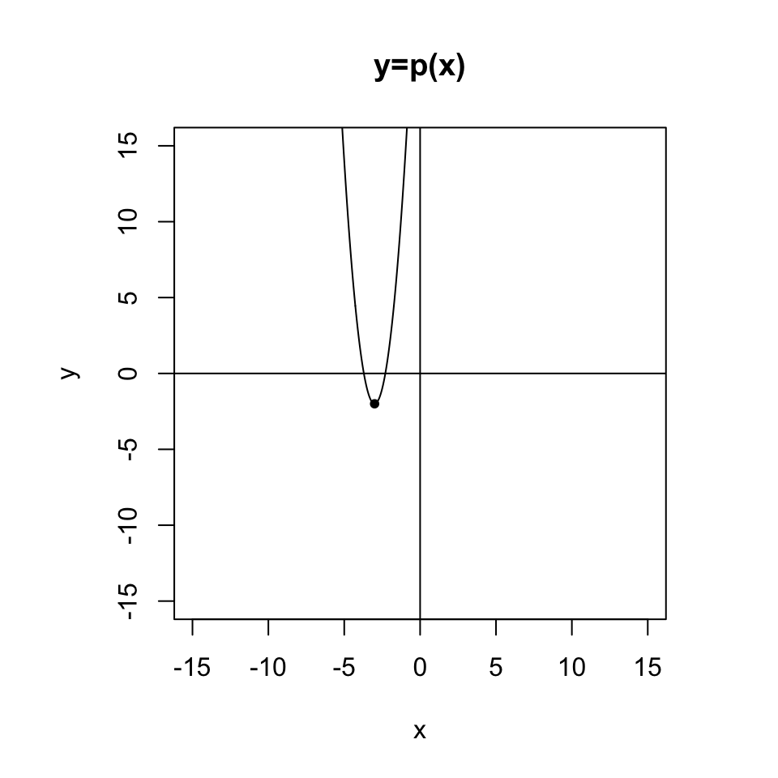

# Meta-information

extype: cloze exclozetype: schoice|schoice exsolution: 000000010000000000000|000000001000000000000 exname: complete_the_square